# HAR Prediction

Genevieve Frenot

May 29, 2019

## Executive Summary

This human activity recognition exercise is based on data from Groupware@LES: http://web.archive.org/web/20161224072740/http:/groupware.les.inf.puc-rio.br/har

In this project, the goal is to use data from accelerometers on the belt, forearm, arm, and dumbell of 6 participants which were asked to perform barbell lifts correctly and incorrectly in 5 different ways.

Our strategy is to split the provided training data in two sets, one for learning and one for testing our model. Once reaching a satisfying accuracy, we would actually validate our model (and hopefully our project assignement) by predicting the exercise classe on the provided test data.

### Data Preparation

Loading the provided training data

```r
data<-read.csv( # read directly from provided URL
    "https://d396qusza40orc.cloudfront.net/predmachlearn/pml-training.csv"
    ,header = TRUE
    ,na.strings = c("NA","NaN","","#DIV/0!")) # mark as NA all invalid entries
dim(data)
```

```
## [1] 19622   160
```

In the appendix you can see some basic data exploration on this provided training set. These 19622 records are a great amount of data sample that we will be able to split for cross validation.

We are now loading the provided test data which we will use as a the final validation set for the project

```r
validation<-read.csv(
    "https://d396qusza40orc.cloudfront.net/predmachlearn/pml-testing.csv"
    , header = TRUE, na.strings = c("NA","NaN","","#DIV/0!"))
dim(validation)
```

```
## [1]  20 160
```

In the appendix you can see some basic data exploration on this provided testing set. These 20 records are the measures for 20 exercises for which we are going to predict the respective classes: A, B, C, D or E

Splitting the provided training data into a training and testing data set for cross validation

```r
inTrain <- createDataPartition(y=data$classe, p=0.75, list=FALSE)
training<- data[inTrain,]
testing <- data[-inTrain,]
```

Creating simplified data set for the prediction model

```r
# removes the outcome
trainingPredictors<-training[,which(names(training)!="classe")]
# Remove columns 1 to 8 which are annotations
trainingPredictors<-trainingPredictors[,-(1:8)]
# Look at the quantity of NA values in the predictors
ratio.na<-function(v) { round(100*sum(is.na(v))/nrow(trainingPredictors)) }
NAs <- sapply(trainingPredictors,ratio.na)
table(NAs)
```

```
## NAs
##   0  98 100
##  51  94   6
```

We can see that 51 predictor columns points are fully populated, and that the others are 98% or 100% empty. As such variables could biaise our analysis, we are removing these colunms from the predictors.

```r
trainingPredictors <- trainingPredictors[,names(NAs[NAs<98])]
```

### Predictor Analysis

Now let’s look at the correlations between the variables of this cleaned set of predictors

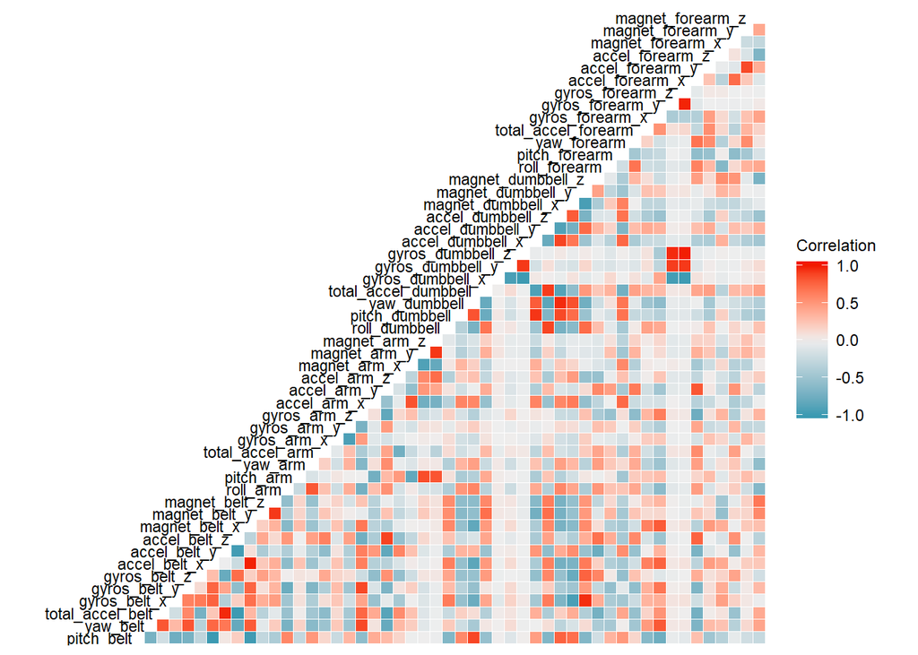

```r
ggcorr(cor(trainingPredictors), size=3, hjust = 1.1, layout.exp = 8
       ,name="Correlation")
```

*Correlation of all valid predictors for the Human Activity test data*

We can see that a many variables are correlated and therefore decide to preprocess the data with Principal Component Analysis

```r
preProc <- preProcess(trainingPredictors,method="pca",pcaComp=ncol(trainingPredictors))
trainingPC <- predict(preProc,trainingPredictors)
```

Just because we are curious, we are visualizing the correlations of this new set of pre-processed predictors.

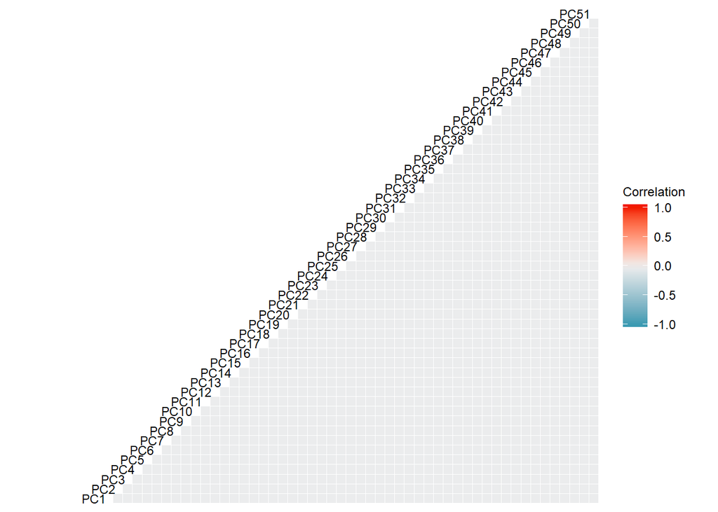

```r
ggcorr(cor(trainingPC), size=3, hjust = 1.1, layout.exp = 8
        ,name="Correlation")
```

*Correlation of the pre-processed predictors for the Human Activity test data*

We can see that these new predictors are nicely independant the ones from the others.

### Building our Prediction Model

With our the pre-processed predictors, we are now ready to build our prediction model. We choose to use Random Forest bootstraping, which takes some time to process but is recognized for its accuracy

```r
modelFit <- train(x = trainingPC, y = training$classe,method="rf")
modelFit$results[modelFit$finalModel$mtry,] # result of the final model
```

```
##   mtry  Accuracy     Kappa  AccuracySD     KappaSD
## 2   26 0.9672361 0.9585468 0.003323737 0.004204737
```

Let’s look in-depth at the final model:

```r
modelFit$finalModel
```

```
##
## Call:
##  randomForest(x = x, y = y, mtry = param$mtry)
##                Type of random forest: classification
##                      Number of trees: 500
## No. of variables tried at each split: 2
##
##         OOB estimate of  error rate: 2.03%
## Confusion matrix:
##      A    B    C    D    E class.error
## A 4175    6    2    1    1 0.002389486
## B   70 2757   20    0    1 0.031952247
## C    3   35 2517   11    1 0.019477990
## D    4    0   96 2301   11 0.046019900
## E    1    8   17   11 2669 0.013673319
```

### Cross Validation

We are now trying our prediction model on the data that we stored separately as out test data

```r
testingPredictors<-testing[,which(names(testing) %in% names(trainingPredictors))]
testingPC <- predict(preProc,testingPredictors)
confusionMatrix<-confusionMatrix(testing$classe,predict(modelFit,testingPC))
confusionMatrix$overall[1]
```

```
## Accuracy
## 0.983279
```

See below a visualization of the prediction vs observations:

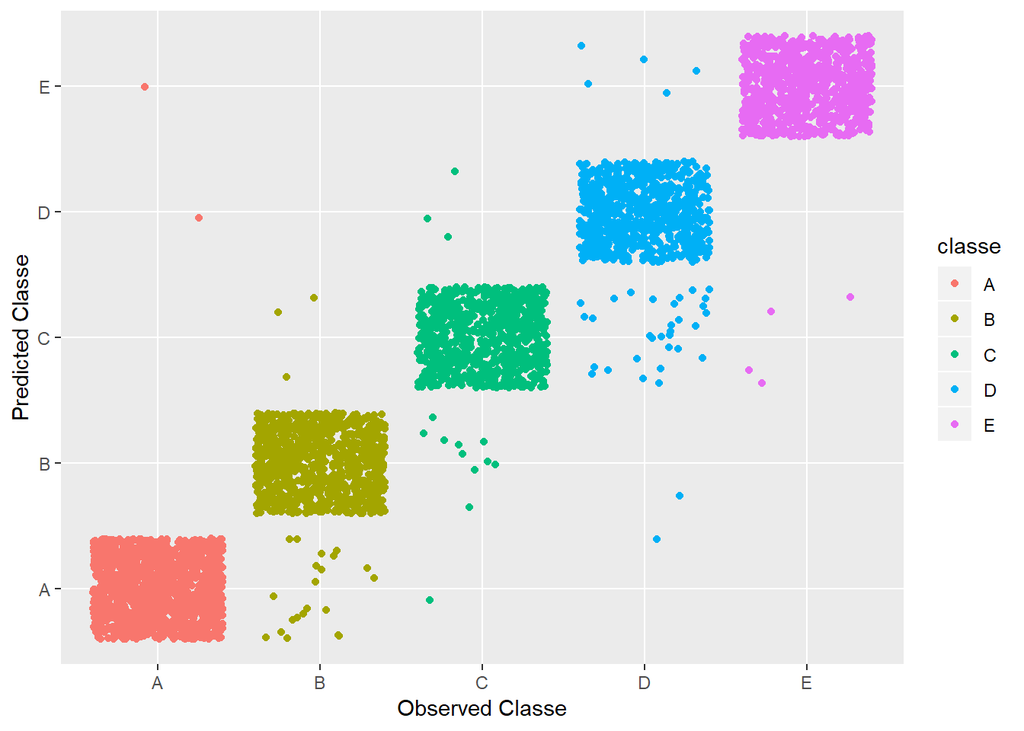

```r
qplot(testing$classe,predict(modelFit,testingPC)
      , colour=classe, data=testing, geom = "jitter"
      , xlab = "Observed Classe", ylab = "Predicted Classe")
```

*Predicted vs. observed in testing data*

As the cross validation demonstrated that the prediction model is satisfactory, we now can use the validation data.

### Final prediction on the validation data

First pre-processing:

```r
validationPredictors<-validation[,which(names(validation) %in% names(trainingPredictors))]
validationPC<-predict(preProc,validationPredictors)
```

Now predicting the outcomes based on the pre-processed data:

```r
prediction<-predict(modelFit,validationPC)
as.data.frame(prediction)
```

```
##    prediction
## 1           B
## 2           A
## 3           B
## 4           A
## 5           A
## 6           E
## 7           D
## 8           B
## 9           A
## 10          A
## 11          B
## 12          C
## 13          B
## 14          A
## 15          E
## 16          E
## 17          A
## 18          B
## 19          B
## 20          B
```

The 20 values above are our prediction to this current human activity recognition exercise. By submitting, we will get the final evaluation of its accuracy.

# Appendix

## Basic data exploration on the provided training set

```r
dim(data)
```

```
## [1] 19622   160
```

```r
str(data[,1:12]) # look at the structure of the 10 first columns
```

```
## 'data.frame':    19622 obs. of  12 variables:
##  $ X                   : int  1 2 3 4 5 6 7 8 9 10 ...
##  $ user_name           : Factor w/ 6 levels "adelmo","carlitos",..: 2 2 2 2 2 2 2 2 2 2 ...
##  $ raw_timestamp_part_1: int  1323084231 1323084231 1323084231 1323084232 1323084232 1323084232 1323084232 1323084232 1323084232 1323084232 ...
##  $ raw_timestamp_part_2: int  788290 808298 820366 120339 196328 304277 368296 440390 484323 484434 ...
##  $ cvtd_timestamp      : Factor w/ 20 levels "02/12/2011 13:32",..: 9 9 9 9 9 9 9 9 9 9 ...
##  $ new_window          : Factor w/ 2 levels "no","yes": 1 1 1 1 1 1 1 1 1 1 ...
##  $ num_window          : int  11 11 11 12 12 12 12 12 12 12 ...
##  $ roll_belt           : num  1.41 1.41 1.42 1.48 1.48 1.45 1.42 1.42 1.43 1.45 ...
##  $ pitch_belt          : num  8.07 8.07 8.07 8.05 8.07 8.06 8.09 8.13 8.16 8.17 ...
##  $ yaw_belt            : num  -94.4 -94.4 -94.4 -94.4 -94.4 -94.4 -94.4 -94.4 -94.4 -94.4 ...
##  $ total_accel_belt    : int  3 3 3 3 3 3 3 3 3 3 ...
##  $ kurtosis_roll_belt  : num  NA NA NA NA NA NA NA NA NA NA ...
```

```r
str(data[,(ncol(data)-6):(ncol(data))]) # look at the 6 last columns
```

```
## 'data.frame':    19622 obs. of  7 variables:
##  $ accel_forearm_x : int  192 192 196 189 189 193 195 193 193 190 ...
##  $ accel_forearm_y : int  203 203 204 206 206 203 205 205 204 205 ...
##  $ accel_forearm_z : int  -215 -216 -213 -214 -214 -215 -215 -213 -214 -215 ...
##  $ magnet_forearm_x: int  -17 -18 -18 -16 -17 -9 -18 -9 -16 -22 ...
##  $ magnet_forearm_y: num  654 661 658 658 655 660 659 660 653 656 ...
##  $ magnet_forearm_z: num  476 473 469 469 473 478 470 474 476 473 ...
##  $ classe          : Factor w/ 5 levels "A","B","C","D",..: 1 1 1 1 1 1 1 1 1 1 ...
```

## Basic data exploration on the provided testing set

```r
dim(validation)
```

```
## [1]  20 160
```

```r
str(data[,1:10]) # look at the structure of the 10 first columns
```

[output not shown]

```r
str(validation[,(ncol(data)-5):(ncol(data))]) # look at the 5 last columns
```

```
## 'data.frame':    20 obs. of  6 variables:
##  $ accel_forearm_y : int  267 297 271 406 -93 322 170 -331 204 98 ...
##  $ accel_forearm_z : int  -149 -118 -129 -39 172 -144 -175 -282 -217 -7 ...
##  $ magnet_forearm_x: int  -714 -237 -51 -233 375 -300 -678 -109 0 -403 ...
##  $ magnet_forearm_y: int  419 791 698 783 -787 800 284 -619 652 723 ...
##  $ magnet_forearm_z: int  617 873 783 521 91 884 585 -32 469 512 ...
##  $ problem_id      : int  1 2 3 4 5 6 7 8 9 10 ...
```

## Prediction model summary

```r
modelFit
```

```
## Random Forest
##
## 14718 samples
##    51 predictor
##     5 classes: 'A', 'B', 'C', 'D', 'E'
##
## No pre-processing
## Resampling: Bootstrapped (25 reps)
## Summary of sample sizes: 14718, 14718, 14718, 14718, 14718, 14718, ...
## Resampling results across tuning parameters:
##
##   mtry  Accuracy   Kappa
##    2    0.9709545  0.9632422
##   26    0.9672361  0.9585468
##   51    0.9539367  0.9417220
##
## Accuracy was used to select the optimal model using the largest value.
## The final value used for the model was mtry = 2.
```

## Confusion matrix

```r
confusionMatrix
```

```
## Confusion Matrix and Statistics
##
##           Reference
## Prediction    A    B    C    D    E
##          A 1393    0    0    1    1
##          B   21  925    3    0    0
##          C    1   10  841    3    0
##          D    1    1   31  766    5
##          E    0    0    4    0  897
##
## Overall Statistics
##
##                Accuracy : 0.9833
##                  95% CI : (0.9793, 0.9867)
##     No Information Rate : 0.2887
##     P-Value [Acc > NIR] : < 2.2e-16
##
##                   Kappa : 0.9788
##
##  Mcnemar's Test P-Value : NA
##
## Statistics by Class:
##
##                      Class: A Class: B Class: C Class: D Class: E
## Sensitivity            0.9838   0.9882   0.9568   0.9948   0.9934
## Specificity            0.9994   0.9940   0.9965   0.9908   0.9990
## Pos Pred Value         0.9986   0.9747   0.9836   0.9527   0.9956
## Neg Pred Value         0.9934   0.9972   0.9906   0.9990   0.9985
## Prevalence             0.2887   0.1909   0.1792   0.1570   0.1841
## Detection Rate         0.2841   0.1886   0.1715   0.1562   0.1829
## Detection Prevalence   0.2845   0.1935   0.1743   0.1639   0.1837
## Balanced Accuracy      0.9916   0.9911   0.9766   0.9928   0.9962
```